# Rによる計量政治学：練習問題の解答例

第6章 記述統計とデータの可視化・視覚化

浅野正彦, 矢内勇生

2018-11-24

## パッケージの読み込み

```r
library("tidyverse")
if (capabilities("aqua")) { # Macかどうか判定し、Macの場合のみ実行
  theme_set(theme_gray(base_size = 10, base_family = "HiraginoSans-W3"))
}
```

## 衆院選データの読み込み

本章の6.1.3節で保存したRds形式の衆院選データ (hr-data.Rds) を読み込む。 手元にない場合はまずダウンロードする。

```r
# dir.create("data") # データディレクトリがない場合は作る
#download.file(url = "https://git.io/fp00p",
#              destfile = "data/hr-data.Rds")
HR <- read_rds("data/hr-data.Rds")
## Rdsファイルの読み込みがうまくいかない場合は以下を実行
#download.file(url = "https://git.io/fxhQU",
#              destfile = "data/hr-data.csv")
#HR <- read_csv("data/hr-data.csv")
```

正しく読み込めたかどうか確認する。

```r
glimpse(HR)
```

```
## Observations: 8,803
## Variables: 22
## $ year       <int> 1996, 1996, 1996, 1996, 1996, 1996, 1996, 1996, 199...
## $ ku         <chr> "aichi", "aichi", "aichi", "aichi", "aichi", "aichi...
## $ kun        <int> 1, 1, 1, 1, 1, 1, 1, 2, 2, 2, 2, 2, 2, 2, 2, 3, 3, ...
## $ status     <fct> 現職, 元職, 現職, 新人, 新人, 新人, 新人, 現職, 元職, 新人, 新人, 新人, 新人,...
## $ name       <chr> "KAWAMURA, TAKASHI", "IMAEDA, NORIO", "SATO, TAISUK...
## $ party      <chr> "NFP", "LDP", "DPJ", "JCP", "others", "kokuminto", ...
## $ party_code <int> 8, 1, 3, 2, 100, 22, 99, 8, 1, 3, 2, 10, 100, 99, 2...
## $ previous   <int> 2, 3, 2, 0, 0, 0, 0, 1, 1, 0, 0, 0, 0, 0, 0, 1, 3, ...
## $ wl         <fct> 当選, 落選, 落選, 落選, 落選, 落選, 落選, 当選, 落選, 復活当選, 落選, 落選, 落...
## $ voteshare  <dbl> 40.0, 25.7, 20.1, 13.3, 0.4, 0.3, 0.2, 32.9, 26.4, ...
## $ age        <int> 47, 72, 53, 43, 51, 51, 45, 51, 71, 30, 31, 44, 61,...
## $ nocand     <int> 7, 7, 7, 7, 7, 7, 7, 8, 8, 8, 8, 8, 8, 8, 8, 7, 7, ...
## $ rank       <int> 1, 2, 3, 4, 5, 6, 7, 1, 2, 3, 4, 5, 6, 7, 8, 1, 2, ...
## $ vote       <int> 66876, 42969, 33503, 22209, 616, 566, 312, 56101, 4...
## $ eligible   <int> 346774, 346774, 346774, 346774, 346774, 346774, 346...
## $ turnout    <dbl> 49.2, 49.2, 49.2, 49.2, 49.2, 49.2, 49.2, 51.8, 51....
## $ exp        <int> 9828097, 9311555, 9231284, 2177203, NA, NA, NA, 129...
## $ expm       <dbl> 9.828097, 9.311555, 9.231284, 2.177203, NA, NA, NA,...
## $ vs         <dbl> 0.400, 0.257, 0.201, 0.133, 0.004, 0.003, 0.002, 0....
## $ exppv      <dbl> 28.341505, 26.851941, 26.620462, 6.278449, NA, NA, ...
## $ smd        <fct> 当選, 落選, 落選, 落選, 落選, 落選, 落選, 当選, 落選, 落選, 落選, 落選, 落選,...
## $ party_jpn  <chr> "新進党", "自民党", "民主党", "共産党", "その他", "国民党", "無所属", "新...
```

## Q6-1

候補者の年齢 age、得票率 voteshare、選挙費用 exp の記述統計を求めてみよう。

```r
HR %>%
  select(age, voteshare, exp) %>%
  summary()
```

```
##       age         voteshare          exp
##  Min.   :25.0   Min.   : 0.10   Min.   :     535
##  1st Qu.:43.0   1st Qu.: 8.90   1st Qu.: 2803566
##  Median :51.0   Median :25.76   Median : 6541589
##  Mean   :50.9   Mean   :27.08   Mean   : 7542700
##  3rd Qu.:59.0   3rd Qu.:42.90   3rd Qu.:11044485
##  Max.   :94.0   Max.   :95.30   Max.   :27462362
##  NA's   :5                      NA's   :2043
```

選挙費用をもう少し詳しく見てみよう。 まず、分散と標準偏差を求める。

```r
var(HR$exp, na.rm = TRUE)  # 分散
```

```
## [1] 3.013017e+13
```

```r
sd(HR$exp, na.rm = TRUE)   # 標準偏差
```

```
## [1] 5489095
```

次に、選挙の年 year ごとに、選挙費用の中央値 (median)、平均値 (mean)、標準偏差 (sd) を求めてみよう。

```r
HR %>%
  group_by(year) %>%
  summarize(median = median(exp, na.rm = TRUE),
            mean = mean(exp, na.rm = TRUE),
            sd = sd(exp, na.rm = TRUE))
```

```
## # A tibble: 8 x 4
##    year   median     mean       sd
##   <int>    <dbl>    <dbl>    <dbl>
## 1  1996 8342580. 9136316. 5996916.
## 2  2000 7111629  8388889. 5838189.
## 3  2003 7188656  7935408. 5461578.
## 4  2005 7696019  8142244. 5569641.
## 5  2009 4809437  6118181. 4997211.
## 6  2012 5381219  5761645. 4109461.
## 7  2014      NA      NaN      NaN
## 8  2017      NA      NaN      NaN
```

2014年と2017年の選挙については、選挙費用が記録されていない（このデータに含まれていないだけ）ことがわかる。

## Q6-2

2012年の選挙だけを取り出し、HR2012というデータフレームを作る。

```r
HR2012 <- filter(HR, year == 2012)
```

### Q6-2-1

小選挙区の当落と復活当選は wl に保存されているので、次のようにすればよい。

```r
HR2012 %>%
  filter(party_jpn == "自民党") %>%
  with(table(wl))
```

```
## wl
##     落選     当選 復活当選
##       13      237       39
```

### Q6-2-3

上と問題の「自民党」を「民主党」に変えればよい。

```r
HR2012 %>%
  filter(party_jpn == "民主党") %>%
  with(table(wl))
```

```
## wl
##     落選     当選 復活当選
##      207       27       30
```

## Q6-3

候補者の名前は、nameにローマ字表記で記載されている。いくつか確認してみよう。

```r
head(HR$name)
```

```
## [1] "KAWAMURA, TAKASHI" "IMAEDA, NORIO"     "SATO, TAISUKE"
## [4] "IWANAKA, MIHOKO"   "ITO, MASAKO"       "YAMADA, HIROSHIB"
```

すべて大文字で、“LAST, FIRST” と保存されていることがわかる。歴代の民主党首相もこの表記で表そう。

```r
pm_dpj <- c("HATOYAMA, YUKIO", "KAN, NAOTO", "NODA, YOSHIHIKO")
```

衆院選データのうち、200年から2009年までの指定された変数を、歴代民主党首相について表示する。

```r
HR %>%
  filter(year >= 2000 & year <= 2009) %>%
  filter(name %in% pm_dpj) %>%
  select(name, year, ku, kun, party, age, nocand, rank, voteshare) %>%
  arrange(name)
```

```
## # A tibble: 12 x 9
##    name             year ku         kun party   age nocand  rank voteshare
##    <chr>           <int> <chr>    <int> <chr> <int>  <int> <int>     <dbl>
##  1 HATOYAMA, YUKIO  2000 hokkaido     9 DPJ      53      3     1      45.5
##  2 HATOYAMA, YUKIO  2003 hokkaido     9 DPJ      56      3     1      50
##  3 HATOYAMA, YUKIO  2005 hokkaido     9 DPJ      58      3     1      49.3
##  4 HATOYAMA, YUKIO  2009 hokkaido     9 DPJ      62      4     1      66.4
##  5 KAN, NAOTO       2000 tokyo       18 DPJ      53      5     1      56.1
##  6 KAN, NAOTO       2003 tokyo       18 DPJ      57      3     1      58.4
##  7 KAN, NAOTO       2005 tokyo       18 DPJ      58      3     1      47.4
##  8 KAN, NAOTO       2009 tokyo       18 DPJ      62      4     1      59.5
##  9 NODA, YOSHIHIKO  2000 chiba        4 DPJ      43      4     1      47.3
## 10 NODA, YOSHIHIKO  2003 chiba        4 DPJ      46      3     1      55.8
## 11 NODA, YOSHIHIKO  2005 chiba        4 DPJ      48      4     1      44.9
## 12 NODA, YOSHIHIKO  2009 chiba        4 DPJ      52      5     1      53.6
```

## Q6-4

### Q6-4-1

政党別に獲得票数 vote の箱ひげ図を作る。

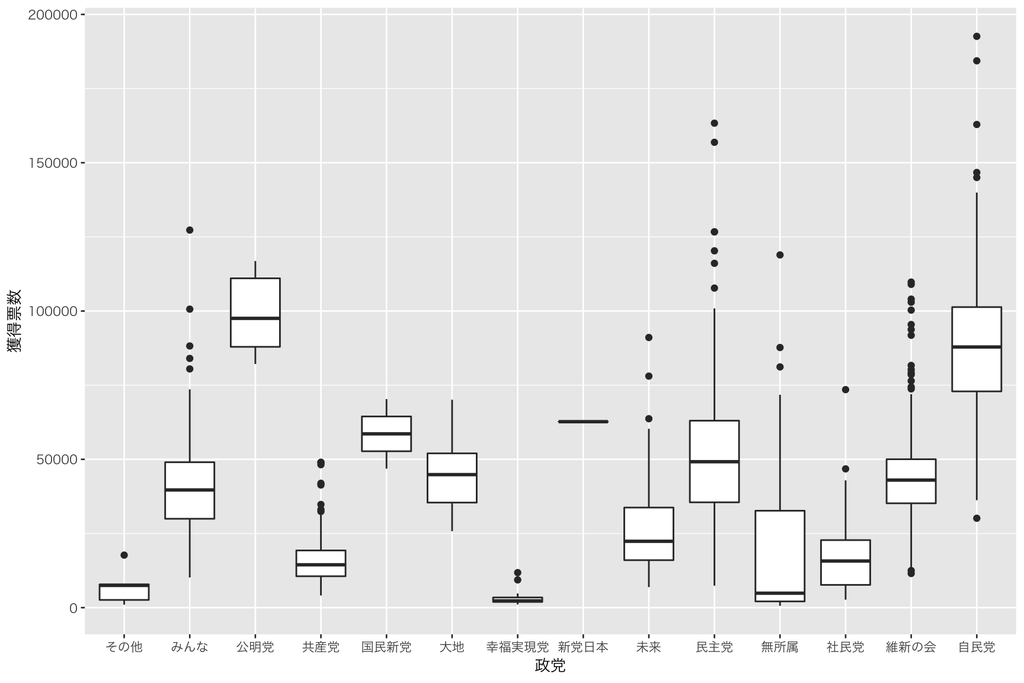

```r
p <- ggplot(data = HR2012, aes(x = party_jpn, y = vote)) +
  geom_boxplot() +
  labs(x = "政党", y = "獲得票数")
print(p)
```

獲得票数の中央値が小さい順に並べるには、次のようにする。

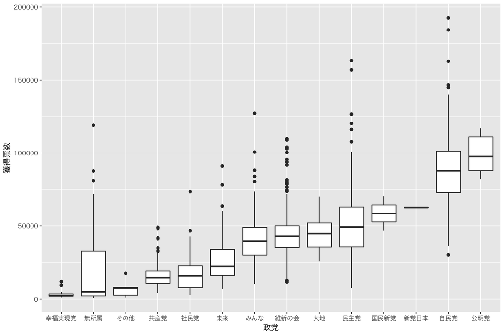

```r
p2 <- ggplot(HR2012,
             aes(x = reorder(x = party_jpn, X = vote, FUN = median),
                 y = vote)) +
  geom_boxplot() +
  labs(x = "政党", y = "獲得票数")
print(p2)
```

### Q6-4-2

自民党の獲得票数の五数要約。

```r
fn_names <- c("min", "Q1", "median", "Q3", "max")
ldp_fn <- HR2012 %>%
  filter(party_jpn == "自民党") %>%
  with(fivenum(vote))
names(ldp_fn) <- fn_names
ldp_fn
```

```
##    min     Q1 median     Q3    max
##  30138  72912  87879 101327 192604
```

民主党の獲得票数の五数要約。

```r
dpj_fn <- HR2012 %>%
  filter(party_jpn == "民主党") %>%
  with(fivenum(vote))
names(dpj_fn) <- fn_names
dpj_fn
```

```
##      min       Q1   median       Q3      max
##   7404.0  35388.5  49198.0  63060.5 163334.0
```